# Selling SPY Weeklys: 2014 - 2018

When To Unwind Positions

Pritam Dalal

February 4, 2019

In our initial 5-year backtest of selling SPY weeklys, we assumed that we would hold positions to maturity. In this analysis, we consider adding a position unwind mechanism.

The mechanism operates at the expiration level as follows:

1. We choose a threshold, call it $t$.
2. For a given expiration, let $p$ be the premium sold for that expiration. When the trade-to-date losses for that expiration exceed $t * p$, we unwind the positions.

In this analysis, we consider thresholds ranging from 10% to 1000% (10x loss). As you might imagine, a 10x loss threshold is the same as having no unwind policy, i.e. holding all positions until maturity.

We restrict this analysis to the daily delta-hedging strategy.

#### Visualizing Performance as a Function of Threshold

In this section we calculate three key performance metrics for loss threshold levels ranging from 10% to 1000%. The three metrics we consider are:

1. annualized average PNL (the numerator of the Sharpe-Ratio)
2. annualized standard deviation of PNL (the denominator of the Sharpe-Ratio)
3. Sharpe-Ratio.

The graphs of each are given below, followed by a few words of commentary:

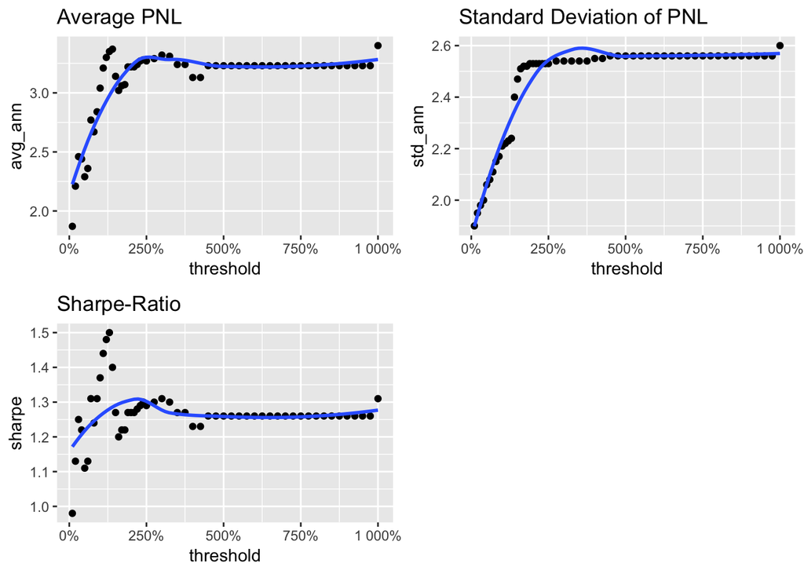

1. Average PNL - a threshold of less than 125% seems to significantly depress returns.
2. Standard Deviation - there is a pop in variability around 125%, but this effect levels off around 250%
3. The Sharpe-Ratio ratio graph has a sweet-spot for a threshold in the range of 110%-135%.

#### Dual Scatter Plots

In this section we look at the two scatter plots, each with a wrinkle. Both scatter plots graph the average annual PNL against the annual standard deviation of the pnl - one pair for corresponding to each threshold. However, instead of simply plotting a dot, we instead plot the threshold amount (left graph) and the Sharpe-Ratio (right graph). This allows us to include three dimensions of data on a 2-D plot.

Because of how the axes of the graphs are laid out, the highest Sharpe-Ratios are in the bottom right, and the lowest Sharpe-Ratios are in the upper left.

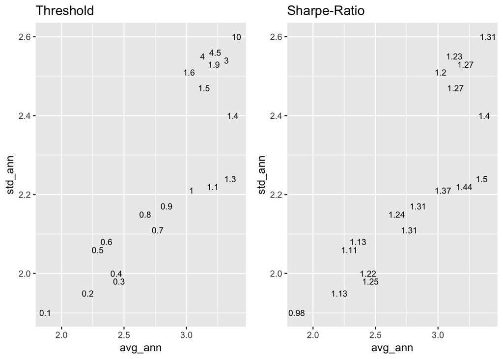

Based on these two graphs, it seems that a threshold of 100%-130% has the highest Sharpe-Ratios. This mirrors the *sweet spot* we observed in the previous section.

#### Conclusion & Recommendation

Based on this analysis, under a daily delta-hedging regiment, I would recommend unwinding positions when losses reach around 125% of premiums sold.

It will be interesting to combine this unwind strategy with the threshold delta-hedging approach, to see if there is an optimal combination of delta-hedging threshold and position unwind threshold.

I will work on the combined analysis next.